# re_stepwise

Lisa Raemy

2025-04-07

# Stepwise forward regression

## Libraries

```r
library(ggplot2)
library(dplyr)
library(tidyverse)
```

# Introduction

In this exercise stepwise forward regression is performed to model GPP as a function of predictors available in the half-hourly ecosystem fluxes dataset. The results are then visualized and discussed.

# Data analysis - stepwise forward regression

## Reading the data and data cleaning

For this analysis the half-hourly ecosystem fluxes dataset is used.

```r
# defining URL of data "df_for_stepwise_fregression.csv"
url_stepwise_regression <- "https://raw.githubusercontent.com/geco-bern/agds_book/refs/heads/main/book/data/df_for_stepwise_regression.csv"

# read the data directly from URL
df_half_hourly_fluxes <- read.table(
  url_stepwise_regression,
  header = TRUE,
  sep = ",",
)
# remove NA
df_half_hourly_fluxes <- df_half_hourly_fluxes |>
  drop_na()
```

## Step 1: Linear Regression with p = 1

For every predictor a linear regression model for GPP is performed. The number of predictors to be considered is p = 1. The variables: “Siteid”, “TIMESTAMP”, “GPP_NT_VUT_REF” and “USTAR” are not included as predictors as they are not physical or meteorological variables. After the fitting of all regression models their R² and AIC are computed and put into a table.

```r
# defining the predictors
predictors <- df_half_hourly_fluxes |>
  names() |>
  setdiff(c("siteid", "TIMESTAMP", "GPP_NT_VUT_REF", "USTAR"))

# defining an empty list for linear regression models
linmods <- list()

for (i in predictors){
  # letting R know to use the whole column and not just the string of i
  formula <- as.formula(paste("GPP_NT_VUT_REF ~", i))

  # calculating linear regression model for every predictor
  linmod <- lm(formula, data = df_half_hourly_fluxes)

  # save models to list, name them after the used predictor
  linmods[[paste0("linmod_", i)]] <- linmod
}


# creating a table with the predictor, R²  and AIC
table1_r2_AIC <- tibble(
  predictor = predictors,
  r_squared = map_dbl(linmods, ~ summary(.)$r.squared),
  AIC = map_dbl(linmods, ~ AIC(.))
)
```

## Visualisation of R² and AIC for every predictor

A plot showing R² and AIC is made. AIC is rescaled to a scale similar to R². R² is visualized as bars and AIC as a line to show both variables in one plot.

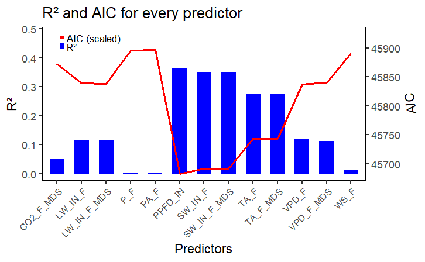

```r
# creating a plot showing R² and AIC for every predictor
plot1_R2_AIC_linmods <- ggplot(
  data = table1_r2_AIC,
  aes(x = predictors)) +
  geom_bar(aes(y = r_squared), stat = "identity", fill ="blue", width = 0.6) +
  # rescalaing AIC to a scale similar to R²
  geom_line(aes(y = (AIC - min(AIC))/10000), group = 1, color = "red", linewidth = 0.8) +
  scale_y_continuous(
    name = "R²",
    sec.axis = sec_axis(~ . *500 + min(table1_r2_AIC$AIC), name = "AIC")
  ) +
  labs(title = "R² and AIC for every predictor",
       x = "Predictors") +
  theme_classic() +
  theme(axis.text.x = element_text(angle = 45, hjust = 1, size = 8),
        axis.title.y.right = element_text(angle = 95)
        ) +
  # Legende hinzufügen
 annotate("rect", xmin = 1, xmax = 2.5, ymin = 0.42, ymax = 0.48, fill = "white") + # weißer Hintergrund
  annotate("segment", x = 1.1, xend = 1.3, y = 0.47, yend = 0.47, color = "red", size = 1) +
  annotate("text", x = 1.4, y = 0.47, label = "AIC (scaled)", hjust = 0, size = 3) +
  annotate("rect", xmin = 1.1, xmax = 1.3, ymin = 0.43, ymax = 0.45, fill = "blue") +
  annotate("text", x = 1.4, y = 0.44, label = "R²", hjust = 0, size = 3)

plot1_R2_AIC_linmods
```

PPFD_IN (13. predictor) has the highest R² (0.363) and lowest AIC (45682.99) and is selected for the next steps of the stepwise forward regression.

## Step 2: Linear Regression with p+1

Now all regression models are fitted with p + 1 predictors, taking PPFD_IN as the selected predictor from the previous step. R² and AIC are then calculated and put into a table.

```r
# defining p + 1 predictors
selected_predictor <- "PPFD_IN"
pplus1_predictors <- setdiff(predictors,  selected_predictor)

# defining an empty list for linear regression models
linmods2 <- list()

for (i in pplus1_predictors) {
  # selecting variables for lm
  formula2 <- as.formula(paste("GPP_NT_VUT_REF ~", selected_predictor, "+", i))

  # calculating linear regression model for p + 1
  linmod2 <- lm(formula2, data = df_half_hourly_fluxes)

  # save models to list, name them after the used predictor
  linmods2[[paste0("linmod2_", i)]] <- linmod2
}

# creating a table with the remaining predictors, R^2 and AIC
table2_r2_AIC <- tibble(
  predictor = pplus1_predictors,
  r_squared = map_dbl(linmods2, ~ summary(.)$r.squared),
  AIC = map_dbl(linmods2, ~ AIC(.))
)
```

## Visualisation of R² and AIC for p + 1 predictors

A plot showing R² and AIC is made again. AIC is rescaled to a scale similar to R². R² is visualized as bars and AIC as a line to show both variables in one plot.

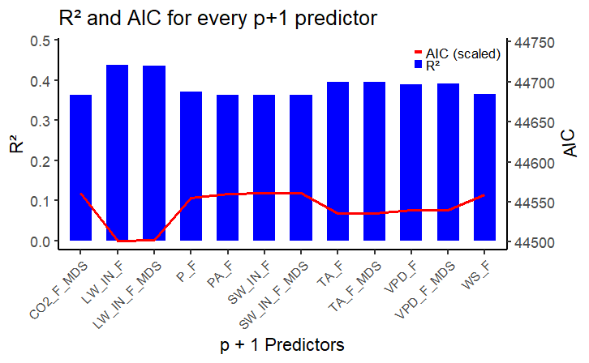

```r
plot2_R2_AIC_linmods <- ggplot(
  data = table2_r2_AIC,
  aes(x = pplus1_predictors)) +
  geom_bar(aes(y = r_squared), stat = "identity", fill ="blue", width = 0.6) +
  # rescaling AIC to a scale similar to R^2
  geom_line(aes(y = (AIC - min(AIC))/10000), group = 1, color = "red", linewidth = 0.8) +
  scale_y_continuous(
    name = "R²",
    sec.axis = sec_axis(~ . *500 + min(table2_r2_AIC$AIC), name = "AIC")
  ) +
  labs(title = "R² and AIC for every p+1 predictor",
       x = "p + 1 Predictors") +
  theme_classic() +
  theme(axis.text.x = element_text(angle = 45, hjust = 1, size = 8),
        axis.title.y.right = element_text(angle = 95)
        ) +
  # Legende hinzufügen
 annotate("rect", xmin = 10, xmax = 11.5, ymin = 0.42, ymax = 0.48, fill = "white") + # weißer Hintergrund
  annotate("segment", x = 10.1, xend = 10.3, y = 0.47, yend = 0.47, color = "red", size = 1) +
  annotate("text", x = 10.4, y = 0.47, label = "AIC (scaled)", hjust = 0, size = 3) +
  annotate("rect", xmin = 10.1, xmax = 10.3, ymin = 0.43, ymax = 0.45, fill = "blue") +
  annotate("text", x = 10.4, y = 0.44, label = "R²", hjust = 0, size = 3)


plot2_R2_AIC_linmods
```

LW_IN_F (3. predictor) has the highest R² (0.437) and the smallest AIC (44501.85).

## Step 3: Linear Regression with p+2

```r
# defining p + 2 predicotrs
selected_predictor2 <- "LW_IN_F"
pplus2_predictors <- setdiff(pplus1_predictors, selected_predictor2)

# defining an empty list for linear regression models
linmods3 <- list()

for (i in pplus2_predictors){
  # selecting variables for lm
  formula3 <- as.formula(paste("GPP_NT_VUT_REF ~", selected_predictor2, "+", i))

  # calculating linear regression model for p + 2
  linmod3 <- lm(formula3, data = df_half_hourly_fluxes)

  # save models to list, name them after the used predictor
  linmods3[[paste0("linmod3_", i)]] <- linmod3
}

# creating a table with the remaining predictors, R^2 and AIC
table3_r2_AIC <- tibble(
  predictors = pplus2_predictors,
  r_squared = map_dbl(linmods3, ~ summary(.)$r.squared),
  AIC = map_dbl(linmods3, ~ AIC(.))
)
```

## Visualization of the stepwise forward regression

```r
# defining a table which shows the progress of the stepwise forward regression
stepwise_progress <- tibble(
  step = c(1:3),
  predictor_added = c("PPFD_IN", "LW_IN_F", "more"),
  predictors_in_model = c("PPFD_IN", " PPFD_IN + LW_IN_F", "more"),
  AIC = c(45682.99, 44501.85, 44648.41),
  R2 = c(0.3627837474, 0.4374452, 0.4286934)
)

# plotting the development of AIC over the steps
plot_stepwise_progress <- ggplot(
  data = stepwise_progress,
  aes (x = step, y = AIC)) +
  geom_line(color = "red")+
  geom_point(size = 2) +
  labs(title = "AIC over the steps of stepwise forward regression",
  x = "Step",
  y = "AIC") +
  theme_classic()

plot_stepwise_progress
```

[output not shown]

# Results

The presumably best model could be found using stepwise forward regression. The linear regression model with p + 1, taking “PPFD_IN” and “LW_IN_F” as predictors for modelling GPP, achieved the best R² (0.4374452) and AIC (44501.85).

# Interpretation

“PPFD_IN” is the primary energy source of photosynthesis which is the foundation of “GPP”. “PPFD_IN”’s strong and direct influence on the total “GPP” explains the high R² and why it was selected as a predictor. But “PPFD_IN” can’t predict GPP alone. Variables like “SW_IN_F” or “CO2_F_MDS” should have also a high influence on “GPP” in theory. But because they are very correlated with “PPFD_IN”, they didn’t really add much new information to the model. That’s why these variables didn’t significantly improve the R² or AIC values in the second step. However “LW_IN_F” provided new information that wasn’t captured by “PPFD_IN” already. This explains why it had the highest R² and was chosen as the second predictor.